# Pravin Prakashrao Kulkarni

https://github.com/pravink83/AIML-FeatureModelSelectionAndTuning.git

```python
# Import Libraries

import warnings
warnings.filterwarnings('ignore')

import pandas as pd
import numpy as np
import matplotlib.pyplot as plt
import seaborn as sns
%matplotlib inline

sns.set(color_codes=True)

from sklearn import preprocessing
from sklearn.linear_model import LinearRegression
from sklearn.linear_model import Ridge
from sklearn.linear_model import Lasso
from sklearn.model_selection import train_test_split
from sklearn.model_selection import KFold
from sklearn.model_selection import cross_validate, cross_val_score
from sklearn.model_selection import GridSearchCV
from sklearn.model_selection import RandomizedSearchCV
from sklearn.svm import SVR, LinearSVR, NuSVR
from sklearn.metrics import mean_squared_error

from mlxtend.feature_selection import SequentialFeatureSelector as sfs
from mlxtend.plotting import plot_sequential_feature_selection as plot_sfs

import statsmodels.api as sm

import json
```

### Load Data

```python
concreteData = pd.read_csv('concrete.csv')

concreteData.head()
```

|  | cement | slag | ash | water | superplastic | coarseagg | fineagg | age | strength |
| --- | --- | --- | --- | --- | --- | --- | --- | --- | --- |
| 0 | 141.3 | 212.0 | 0.0 | 203.5 | 0.0 | 971.8 | 748.5 | 28 | 29.89 |
| 1 | 168.9 | 42.2 | 124.3 | 158.3 | 10.8 | 1080.8 | 796.2 | 14 | 23.51 |
| 2 | 250.0 | 0.0 | 95.7 | 187.4 | 5.5 | 956.9 | 861.2 | 28 | 29.22 |
| 3 | 266.0 | 114.0 | 0.0 | 228.0 | 0.0 | 932.0 | 670.0 | 28 | 45.85 |
| 4 | 154.8 | 183.4 | 0.0 | 193.3 | 9.1 | 1047.4 | 696.7 | 28 | 18.29 |

# Deliverable – 1

## Univariate analysis

```python
# Shape of data
concreteData.shape
```

```
(1030, 9)
```

```python
rowCount = concreteData.shape[0]
rowCount
```

```
1030
```

```python
# Data Types
concreteData.dtypes
```

```
cement          float64
slag            float64
ash             float64
water           float64
superplastic    float64
coarseagg       float64
fineagg         float64
age               int64
strength        float64
dtype: object
```

```python
# Null check
concreteData.isnull().sum()
```

```
cement          0
slag            0
ash             0
water           0
superplastic    0
coarseagg       0
fineagg         0
age             0
strength        0
dtype: int64
```

```python
# number of unique values
concreteData.nunique()
```

```
cement          278
slag            185
ash             156
water           195
superplastic    111
coarseagg       284
fineagg         302
age              14
strength        845
dtype: int64
```

```python
# Unique values & counts i.e. value counts

for col in concreteData.columns:
    print('----------- Value Counts of ', col, ' -----------')
    print(concreteData.groupby(by=col)[col].value_counts())
    print('-------------------------------------')
    print()
```

```
----------- Value Counts of  cement  -----------
cement  cement
102.0   102.0     4
108.3   108.3     4
116.0   116.0     4
122.6   122.6     4
132.0   132.0     2
                 ..
522.0   522.0     2
525.0   525.0     7
528.0   528.0     1
531.3   531.3     5
540.0   540.0     9
Name: cement, Length: 278, dtype: int64
-------------------------------------

----------- Value Counts of  slag  -----------
slag   slag
0.0    0.0      471
11.0   11.0       4
13.6   13.6       5
15.0   15.0       5
17.2   17.2       1
               ...
290.2  290.2      2
305.3  305.3      4
316.1  316.1      2
342.1  342.1      2
359.4  359.4      2
Name: slag, Length: 185, dtype: int64
-------------------------------------

----------- Value Counts of  ash  -----------
ash    ash
0.0    0.0      566
24.5   24.5      15
59.0   59.0       1
60.0   60.0       1
71.0   71.0       1
               ...
```

[output cut: 91 more lines]

```
----------- Value Counts of  strength  -----------
strength  strength
2.33      2.33        1
3.32      3.32        1
4.57      4.57        1
4.78      4.78        1
4.83      4.83        1
                     ..
79.40     79.40       1
79.99     79.99       1
80.20     80.20       1
81.75     81.75       1
82.60     82.60       1
Name: strength, Length: 845, dtype: int64
-------------------------------------
```

```python
# Statistical summary of numeric columns
concreteData.describe().T
```

|  | count | mean | std | min | 25% | 50% | 75% | max |
| --- | --- | --- | --- | --- | --- | --- | --- | --- |
| cement | 1030.0 | 281.167864 | 104.506364 | 102.00 | 192.375 | 272.900 | 350.000 | 540.0 |
| slag | 1030.0 | 73.895825 | 86.279342 | 0.00 | 0.000 | 22.000 | 142.950 | 359.4 |
| ash | 1030.0 | 54.188350 | 63.997004 | 0.00 | 0.000 | 0.000 | 118.300 | 200.1 |
| water | 1030.0 | 181.567282 | 21.354219 | 121.80 | 164.900 | 185.000 | 192.000 | 247.0 |
| superplastic | 1030.0 | 6.204660 | 5.973841 | 0.00 | 0.000 | 6.400 | 10.200 | 32.2 |
| coarseagg | 1030.0 | 972.918932 | 77.753954 | 801.00 | 932.000 | 968.000 | 1029.400 | 1145.0 |
| fineagg | 1030.0 | 773.580485 | 80.175980 | 594.00 | 730.950 | 779.500 | 824.000 | 992.6 |
| age | 1030.0 | 45.662136 | 63.169912 | 1.00 | 7.000 | 28.000 | 56.000 | 365.0 |
| strength | 1030.0 | 35.817961 | 16.705742 | 2.33 | 23.710 | 34.445 | 46.135 | 82.6 |

```python
def getQuartileCounts(col):
    print('Quartile Analysis of ', col)
    print()
    Min = concreteData[col].min()
    Max = concreteData[col].max()
    Std = concreteData[col].std()
    Mean = concreteData[col].mean()
    Median = concreteData[col].median()
    Q1 = concreteData[col].quantile(q=0.25)
    Q2 = concreteData[col].quantile(q=0.50)
    Q3 = concreteData[col].quantile(q=0.75)
    IQR = Q3-Q1
    Minimum = Q1 - (1.5 * IQR)
    Maximum = Q3 + (1.5 * IQR)
    LeftOutlierCount = concreteData[concreteData[col]<Minimum].shape[0]
    Q1Count = concreteData[(concreteData[col]>=Minimum) & (concreteData[col]<=Q1)].shape[0]
    Q2Count = concreteData[(concreteData[col]>Q1) & (concreteData[col]<=Q2)].shape[0]
    Q3Count = concreteData[(concreteData[col]>Q2) & (concreteData[col]<=Q3)].shape[0]
    Q4Count = concreteData[(concreteData[col]>Q3) & (concreteData[col]<=Maximum)].shape[0]
    RightOutlierCount = concreteData[concreteData[col]>Maximum].shape[0]
    print('Min ', Min, " Value count: ", concreteData[concreteData[col] == Min].shape[0])
    print('Max ', Max, " Value count: ", concreteData[concreteData[col] == Max].shape[0])
    print()
    print('Standard Deviation ', Std)
    print('Mean ', Mean)
    print('Median ', Median)
    print()
    print('25th percentile Q1 ', Q1)
    print('50th percentile Q2 ', Q2)
    print('75th percentile Q3 ', Q3)
    print('IQR ', IQR)
    print('Minimum = Q1 - 1.5*IQR = ', Minimum)
    print('Maximum = Q3 + 1.5*IQR = ', Maximum)
    print()
    print('Left outlier count i.e. < Minimum  ', LeftOutlierCount)
    print('>= Minimum and <= Q1 count         ', Q1Count)
    print('> Q1 and <= Q2 count               ', Q2Count)
    print('> Q2 and <= Q3 count               ', Q3Count)
    print('> Q3 and <= Maximum                ', Q4Count)
    print('Right outlier count i.e. > Maximum ', RightOutlierCount)
    print('Total Outliers ', (LeftOutlierCount+RightOutlierCount), '  ', (LeftOutlierCount+RightOutlierCount)*100/rowCount, '%', ' of total records')
    print()
    if(Mean > Median):
        print('Distribution is Right Skewed because Mean > Median')
    elif(Mean < Median):
        print('Distribution is Left Skewed because Mean < Median')
    else:
        print('Distribution is Symmetric because Mean = Median')


def plotUnivariate(col, pltType):
    if (pltType == 'box-dist'):
        fig, axes = plt.subplots(1, 2, figsize=[15,5])
        fig.tight_layout(pad=5.0)
        getQuartileCounts(col)
        sns.boxplot(data=concreteData, x=col, ax=axes[0]);
        sns.distplot(concreteData[col], ax=axes[1]);
```

```
Quartile Analysis of  cement

Min  102.0  Value count:  4
Max  540.0  Value count:  9

Standard Deviation  104.50636449481536
Mean  281.1678640776698
Median  272.9

25th percentile Q1  192.375
50th percentile Q2  272.9
75th percentile Q3  350.0
IQR  157.625
Minimum = Q1 - 1.5*IQR =  -44.0625
Maximum = Q3 + 1.5*IQR =  586.4375

Left outlier count i.e. < Minimum   0
>= Minimum and <= Q1 count          258
> Q1 and <= Q2 count                257
> Q2 and <= Q3 count                259
> Q3 and <= Maximum                 256
Right outlier count i.e. > Maximum  0
Total Outliers  0    0.0 %  of total records

Distribution is Right Skewed because Mean > Median
```

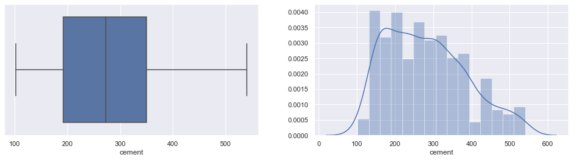

```python
# Plot for cement
plotUnivariate('cement', 'box-dist')
```

```
Quartile Analysis of  slag

Min  0.0  Value count:  471
Max  359.4  Value count:  2

Standard Deviation  86.2793417481054
Mean  73.89582524271844
Median  22.0

25th percentile Q1  0.0
50th percentile Q2  22.0
75th percentile Q3  142.95
IQR  142.95
Minimum = Q1 - 1.5*IQR =  -214.42499999999998
Maximum = Q3 + 1.5*IQR =  357.375

Left outlier count i.e. < Minimum   0
>= Minimum and <= Q1 count          471
> Q1 and <= Q2 count                47
> Q2 and <= Q3 count                254
> Q3 and <= Maximum                 256
Right outlier count i.e. > Maximum  2
Total Outliers  2    0.1941747572815534 %  of total records

Distribution is Right Skewed because Mean > Median
```

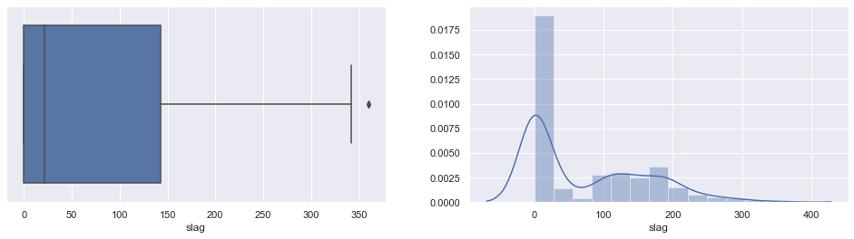

```python
# Plot for slag
plotUnivariate('slag', 'box-dist')
```

```
Quartile Analysis of  ash

Min  0.0  Value count:  566
Max  200.1  Value count:  1

Standard Deviation  63.99700415268794
Mean  54.188349514563086
Median  0.0

25th percentile Q1  0.0
50th percentile Q2  0.0
75th percentile Q3  118.3
IQR  118.3
Minimum = Q1 - 1.5*IQR =  -177.45
Maximum = Q3 + 1.5*IQR =  295.75

Left outlier count i.e. < Minimum   0
>= Minimum and <= Q1 count          566
> Q1 and <= Q2 count                0
> Q2 and <= Q3 count                222
> Q3 and <= Maximum                 242
Right outlier count i.e. > Maximum  0
Total Outliers  0    0.0 %  of total records

Distribution is Right Skewed because Mean > Median
```

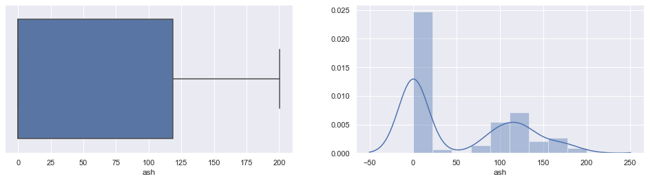

```python
# Plot for ash
plotUnivariate('ash', 'box-dist')
```

```
Quartile Analysis of  water

Min  121.8  Value count:  5
Max  247.0  Value count:  1

Standard Deviation  21.35421856503245
Mean  181.56728155339798
Median  185.0

25th percentile Q1  164.9
50th percentile Q2  185.0
75th percentile Q3  192.0
IQR  27.099999999999994
Minimum = Q1 - 1.5*IQR =  124.25000000000001
Maximum = Q3 + 1.5*IQR =  232.64999999999998

Left outlier count i.e. < Minimum   5
>= Minimum and <= Q1 count          261
> Q1 and <= Q2 count                254
> Q2 and <= Q3 count                257
> Q3 and <= Maximum                 249
Right outlier count i.e. > Maximum  4
Total Outliers  9    0.8737864077669902 %  of total records

Distribution is Left Skewed because Mean < Median
```

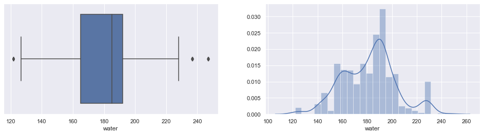

```python
# Plot for water
plotUnivariate('water', 'box-dist')
```

```
Quartile Analysis of  superplastic

Min  0.0  Value count:  379
Max  32.2  Value count:  5

Standard Deviation  5.973841392485508
Mean  6.204660194174756
Median  6.4

25th percentile Q1  0.0
50th percentile Q2  6.4
75th percentile Q3  10.2
IQR  10.2
Minimum = Q1 - 1.5*IQR =  -15.299999999999999
Maximum = Q3 + 1.5*IQR =  25.5

Left outlier count i.e. < Minimum   0
>= Minimum and <= Q1 count          379
> Q1 and <= Q2 count                139
> Q2 and <= Q3 count                256
> Q3 and <= Maximum                 246
Right outlier count i.e. > Maximum  10
Total Outliers  10    0.970873786407767 %  of total records

Distribution is Left Skewed because Mean < Median
```

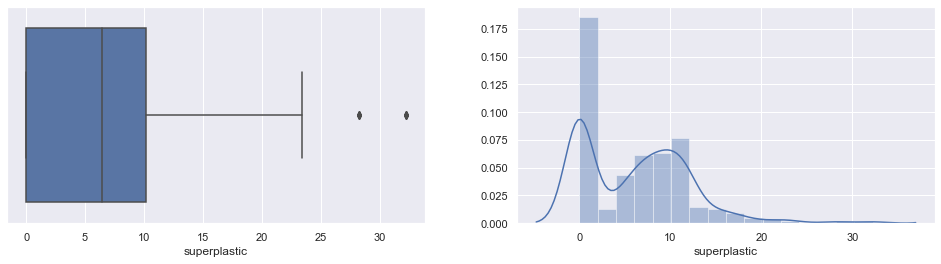

```python
# Plot for superplastic
plotUnivariate('superplastic', 'box-dist')
```

```
Quartile Analysis of  coarseagg

Min  801.0  Value count:  4
Max  1145.0  Value count:  1

Standard Deviation  77.75395396672087
Mean  972.918932038835
Median  968.0

25th percentile Q1  932.0
50th percentile Q2  968.0
75th percentile Q3  1029.4
IQR  97.40000000000009
Minimum = Q1 - 1.5*IQR =  785.8999999999999
Maximum = Q3 + 1.5*IQR =  1175.5000000000002

Left outlier count i.e. < Minimum   0
>= Minimum and <= Q1 count          301
> Q1 and <= Q2 count                235
> Q2 and <= Q3 count                239
> Q3 and <= Maximum                 255
Right outlier count i.e. > Maximum  0
Total Outliers  0    0.0 %  of total records

Distribution is Right Skewed because Mean > Median
```

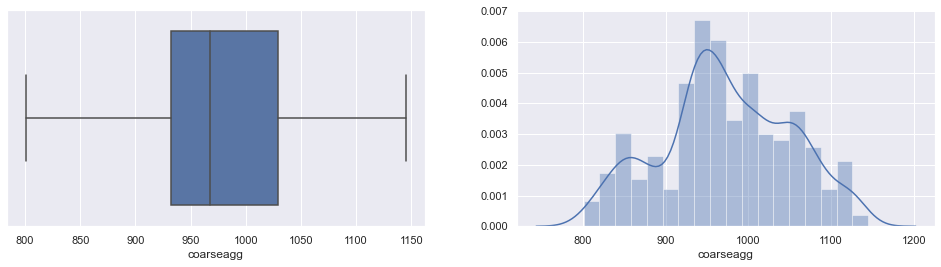

```python
# Plot for coarseagg
plotUnivariate('coarseagg', 'box-dist')
```

```
Quartile Analysis of  fineagg

Min  594.0  Value count:  30
Max  992.6  Value count:  5

Standard Deviation  80.17598014240443
Mean  773.5804854368932
Median  779.5

25th percentile Q1  730.9499999999999
50th percentile Q2  779.5
75th percentile Q3  824.0
IQR  93.05000000000007
Minimum = Q1 - 1.5*IQR =  591.3749999999998
Maximum = Q3 + 1.5*IQR =  963.575

Left outlier count i.e. < Minimum   0
>= Minimum and <= Q1 count          258
> Q1 and <= Q2 count                257
> Q2 and <= Q3 count                258
> Q3 and <= Maximum                 252
Right outlier count i.e. > Maximum  5
Total Outliers  5    0.4854368932038835 %  of total records

Distribution is Left Skewed because Mean < Median
```

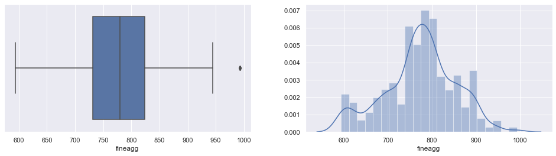

```python
# Plot for fineagg
plotUnivariate('fineagg', 'box-dist')
```

```
Quartile Analysis of  age

Min  1  Value count:  2
Max  365  Value count:  14

Standard Deviation  63.16991158103279
Mean  45.662135922330094
Median  28.0

25th percentile Q1  7.0
50th percentile Q2  28.0
75th percentile Q3  56.0
IQR  49.0
Minimum = Q1 - 1.5*IQR =  -66.5
Maximum = Q3 + 1.5*IQR =  129.5

Left outlier count i.e. < Minimum   0
>= Minimum and <= Q1 count          262
> Q1 and <= Q2 count                487
> Q2 and <= Q3 count                91
> Q3 and <= Maximum                 131
Right outlier count i.e. > Maximum  59
Total Outliers  59    5.728155339805825 %  of total records

Distribution is Right Skewed because Mean > Median
```

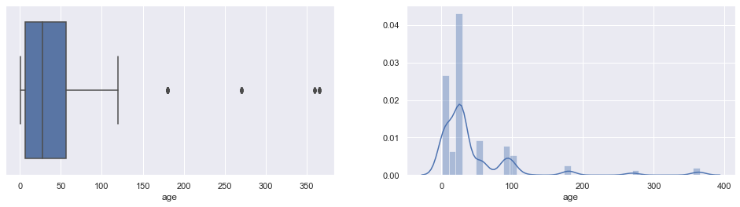

```python
# Plot for age
plotUnivariate('age', 'box-dist')
```

```
Quartile Analysis of  strength

Min  2.33  Value count:  1
Max  82.6  Value count:  1

Standard Deviation  16.70574196191251
Mean  35.81796116504854
Median  34.445

25th percentile Q1  23.709999999999997
50th percentile Q2  34.445
75th percentile Q3  46.135000000000005
IQR  22.425000000000008
Minimum = Q1 - 1.5*IQR =  -9.927500000000013
Maximum = Q3 + 1.5*IQR =  79.77250000000001

Left outlier count i.e. < Minimum   0
>= Minimum and <= Q1 count          258
> Q1 and <= Q2 count                257
> Q2 and <= Q3 count                257
> Q3 and <= Maximum                 254
Right outlier count i.e. > Maximum  4
Total Outliers  4    0.3883495145631068 %  of total records

Distribution is Right Skewed because Mean > Median
```

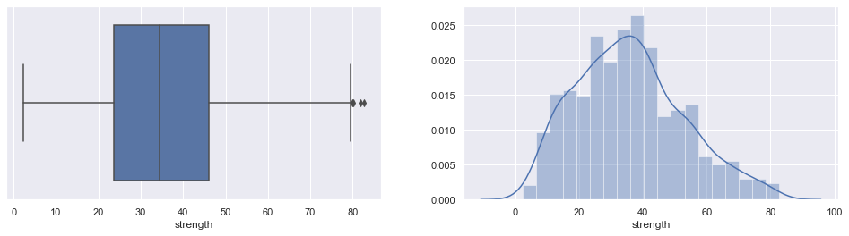

```python
# Plot for strength
plotUnivariate('strength', 'box-dist')
```

## Multivariate analysis

```python
# Find the correlation coefficients.

concreteData.corr()
```

|  | cement | slag | ash | water | superplastic | coarseagg | fineagg | age | strength |
| --- | --- | --- | --- | --- | --- | --- | --- | --- | --- |
| cement | 1.000000 | -0.275216 | -0.397467 | -0.081587 | 0.092386 | -0.109349 | -0.222718 | 0.081946 | 0.497832 |
| slag | -0.275216 | 1.000000 | -0.323580 | 0.107252 | 0.043270 | -0.283999 | -0.281603 | -0.044246 | 0.134829 |
| ash | -0.397467 | -0.323580 | 1.000000 | -0.256984 | 0.377503 | -0.009961 | 0.079108 | -0.154371 | -0.105755 |
| water | -0.081587 | 0.107252 | -0.256984 | 1.000000 | -0.657533 | -0.182294 | -0.450661 | 0.277618 | -0.289633 |
| superplastic | 0.092386 | 0.043270 | 0.377503 | -0.657533 | 1.000000 | -0.265999 | 0.222691 | -0.192700 | 0.366079 |
| coarseagg | -0.109349 | -0.283999 | -0.009961 | -0.182294 | -0.265999 | 1.000000 | -0.178481 | -0.003016 | -0.164935 |
| fineagg | -0.222718 | -0.281603 | 0.079108 | -0.450661 | 0.222691 | -0.178481 | 1.000000 | -0.156095 | -0.167241 |
| age | 0.081946 | -0.044246 | -0.154371 | 0.277618 | -0.192700 | -0.003016 | -0.156095 | 1.000000 | 0.328873 |
| strength | 0.497832 | 0.134829 | -0.105755 | -0.289633 | 0.366079 | -0.164935 | -0.167241 | 0.328873 | 1.000000 |

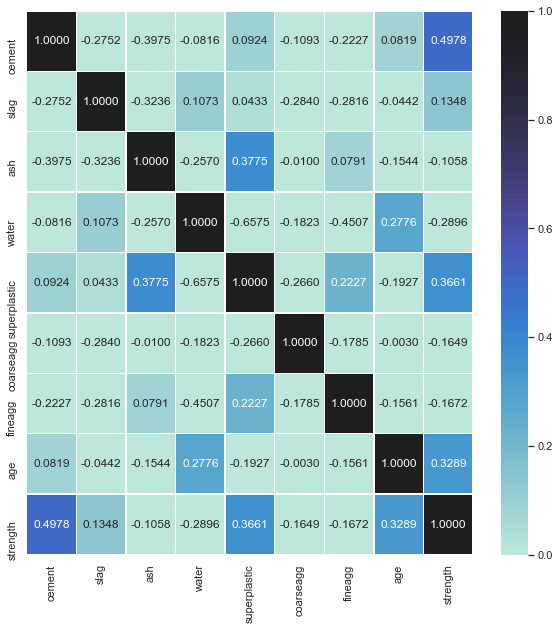

```python
# Create a heatmap to see how the variables relate
fig = plt.figure(figsize=[10,10])
sns.heatmap(concreteData.corr(), annot=True, linewidths=.5, fmt= '.4f', center = 1, vmin=0, vmax=1);
```

```python
# The data needs to be normalized to compare the patterns.
# Using the StandardScaler for the normalization.

scalar = preprocessing.StandardScaler()

concreteDataScaled = pd.DataFrame(scalar.fit_transform(concreteData), columns=concreteData.columns)
concreteDataScaled.head()
```

|  | cement | slag | ash | water | superplastic | coarseagg | fineagg | age | strength |
| --- | --- | --- | --- | --- | --- | --- | --- | --- | --- |
| 0 | -1.339017 | 1.601441 | -0.847144 | 1.027590 | -1.039143 | -0.014398 | -0.312970 | -0.279733 | -0.355018 |
| 1 | -1.074790 | -0.367541 | 1.096078 | -1.090116 | 0.769617 | 1.388141 | 0.282260 | -0.501465 | -0.737108 |
| 2 | -0.298384 | -0.856888 | 0.648965 | 0.273274 | -0.118015 | -0.206121 | 1.093371 | -0.279733 | -0.395144 |
| 3 | -0.145209 | 0.465044 | -0.847144 | 2.175461 | -1.039143 | -0.526517 | -1.292542 | -0.279733 | 0.600806 |
| 4 | -1.209776 | 1.269798 | -0.847144 | 0.549700 | 0.484905 | 0.958372 | -0.959363 | -0.279733 | -1.049727 |

```python
# Verify if the correlation coefficients change due scaling
concreteDataScaled.corr()
```

|  | cement | slag | ash | water | superplastic | coarseagg | fineagg | age | strength |
| --- | --- | --- | --- | --- | --- | --- | --- | --- | --- |
| cement | 1.000000 | -0.275216 | -0.397467 | -0.081587 | 0.092386 | -0.109349 | -0.222718 | 0.081946 | 0.497832 |
| slag | -0.275216 | 1.000000 | -0.323580 | 0.107252 | 0.043270 | -0.283999 | -0.281603 | -0.044246 | 0.134829 |
| ash | -0.397467 | -0.323580 | 1.000000 | -0.256984 | 0.377503 | -0.009961 | 0.079108 | -0.154371 | -0.105755 |
| water | -0.081587 | 0.107252 | -0.256984 | 1.000000 | -0.657533 | -0.182294 | -0.450661 | 0.277618 | -0.289633 |
| superplastic | 0.092386 | 0.043270 | 0.377503 | -0.657533 | 1.000000 | -0.265999 | 0.222691 | -0.192700 | 0.366079 |
| coarseagg | -0.109349 | -0.283999 | -0.009961 | -0.182294 | -0.265999 | 1.000000 | -0.178481 | -0.003016 | -0.164935 |
| fineagg | -0.222718 | -0.281603 | 0.079108 | -0.450661 | 0.222691 | -0.178481 | 1.000000 | -0.156095 | -0.167241 |
| age | 0.081946 | -0.044246 | -0.154371 | 0.277618 | -0.192700 | -0.003016 | -0.156095 | 1.000000 | 0.328873 |
| strength | 0.497832 | 0.134829 | -0.105755 | -0.289633 | 0.366079 | -0.164935 | -0.167241 | 0.328873 | 1.000000 |

```python
# Bivariate - BoxPlots & Density Curves & Scatter Plots
def plotBivariate(col1, col2):
    figure, axes = plt.subplots(2, 2, figsize=(15,10))
    figure.tight_layout(pad=5.0)

    sns.boxplot(data=concreteDataScaled, x=col1, color="r", ax=axes[0,0])
    sns.boxplot(data=concreteDataScaled, x=col2, color="b", ax=axes[0,0]);

    sns.kdeplot(concreteDataScaled[col1], shade=True, color="r", ax=axes[0,1])
    sns.kdeplot(concreteDataScaled[col2], shade=True, color="b", ax=axes[0,1]);

    sns.distplot(concreteDataScaled[col1], color="r", kde=False, ax=axes[1,0])
    sns.distplot(concreteDataScaled[col2], color="b", kde=False, ax=axes[1,0]);

    sns.scatterplot(data=concreteDataScaled, x=col1, y=col2, ax=axes[1,1]);
```

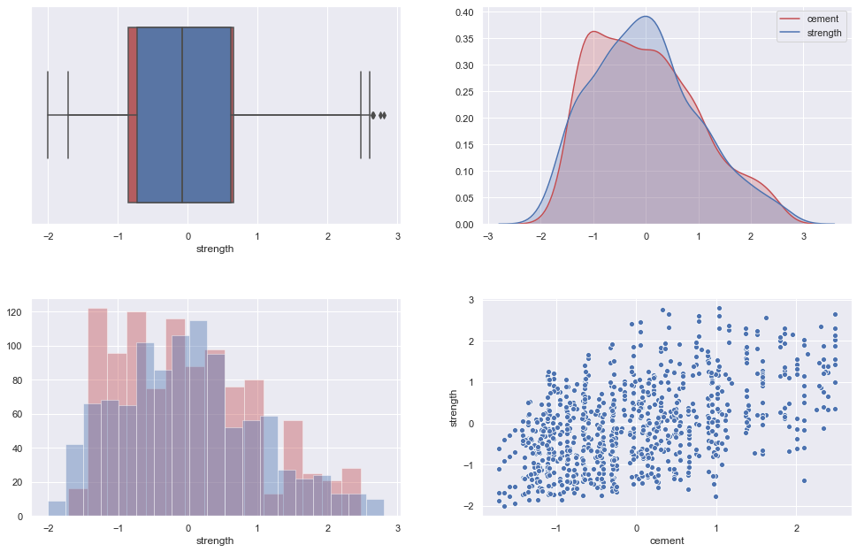

```python
# 'cement' v/s 'strength'

plotBivariate('cement', 'strength')
```

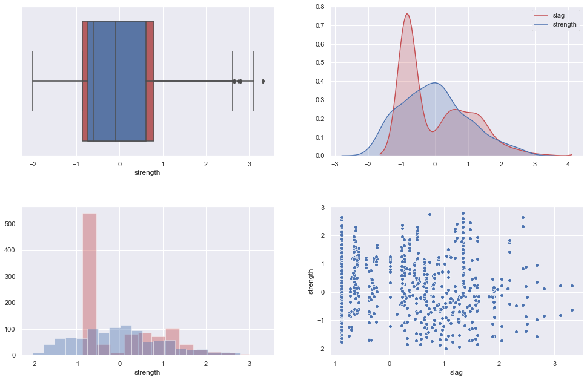

```python
# 'slag' v/s 'strength'

plotBivariate('slag', 'strength')
```

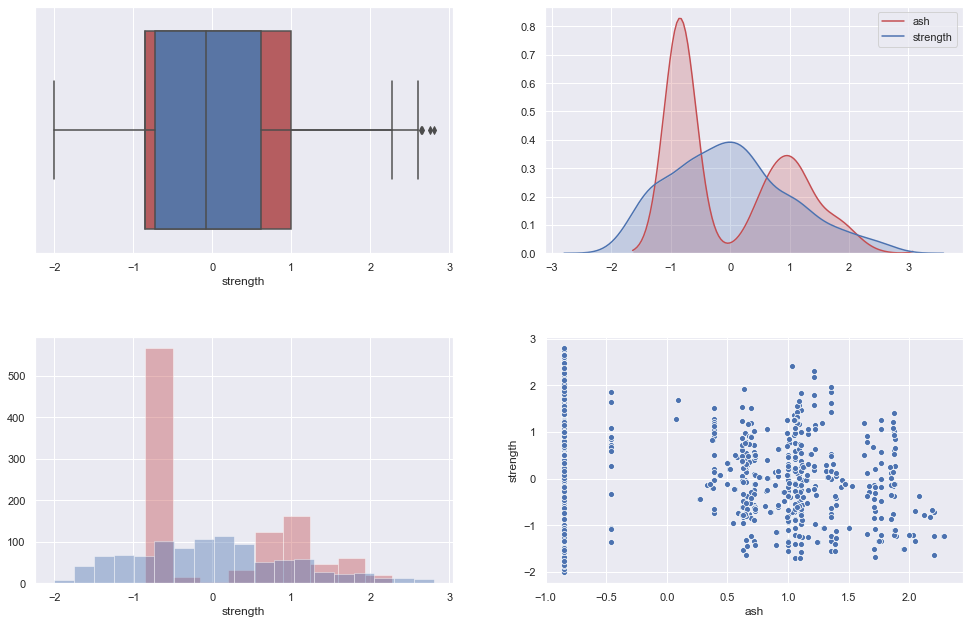

```python
# 'ash' v/s 'strength'

plotBivariate('ash', 'strength')
```

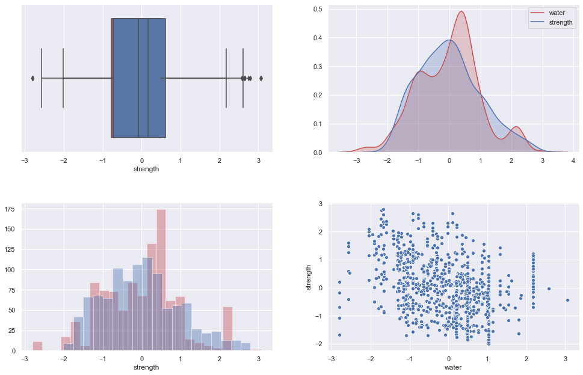

```python
# 'water' v/s 'strength'

plotBivariate('water', 'strength')
```

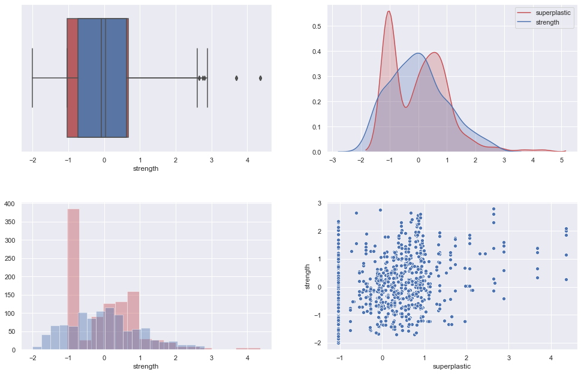

```python
# 'superplastic' v/s 'strength'

plotBivariate('superplastic', 'strength')
```

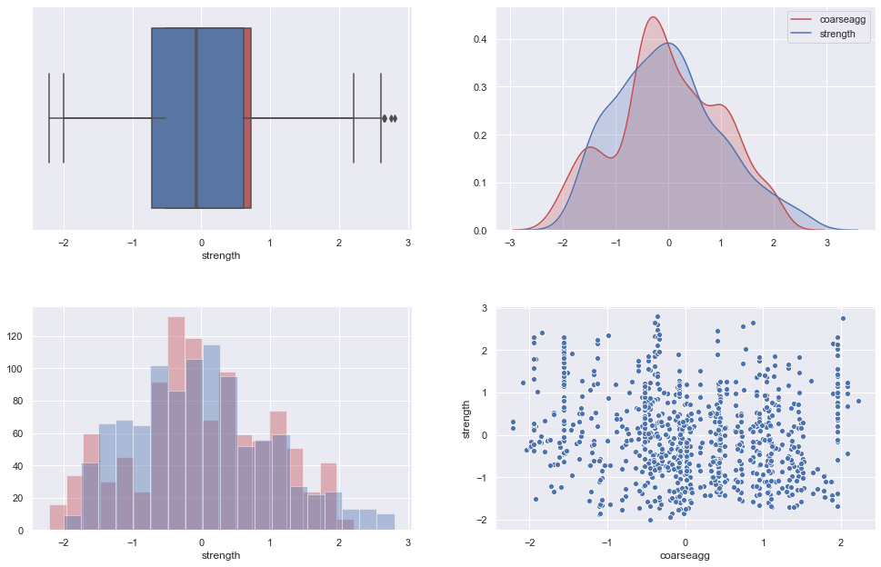

```python
# 'coarseagg' v/s 'strength'

plotBivariate('coarseagg', 'strength')
```

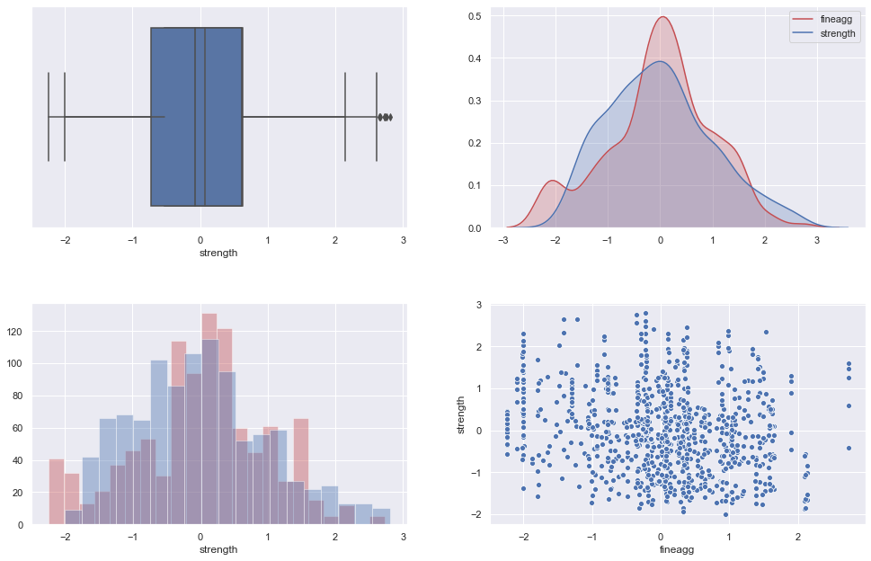

```python
# 'fineagg' v/s 'strength'

plotBivariate('fineagg', 'strength')
```

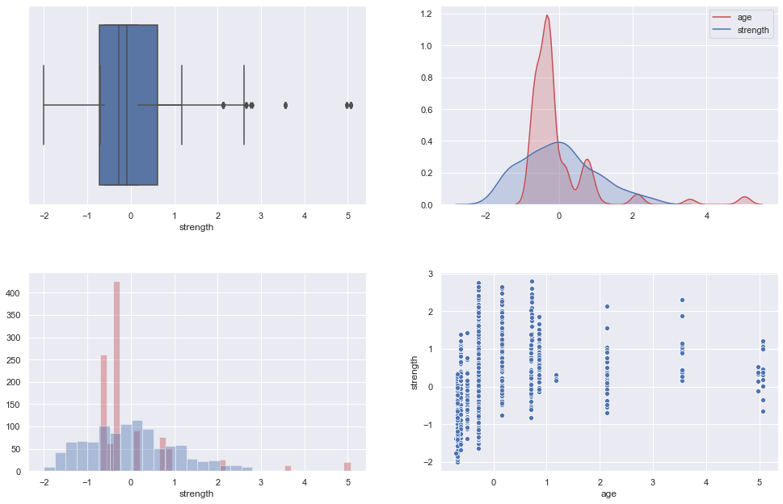

```python
# 'age' v/s 'strength'

plotBivariate('age', 'strength')
```

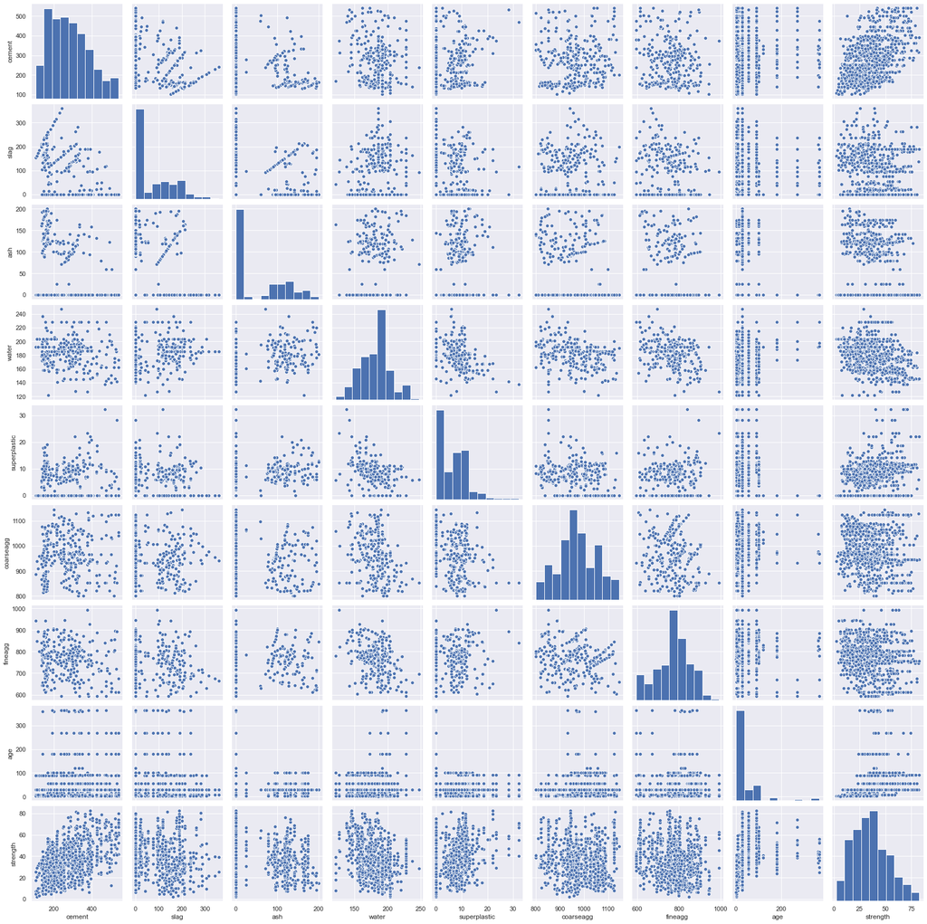

```python
# Pair plot
sns.pairplot(concreteData);
```

## Observations

- Cement and Concrete compressive strength are positively correlated. Degree of Correlation 0.497832
- Blast Furnace Slag (slag) and Concrete compressive strength are very weakly positively correlated. Degree of Correlation 0.134829
- Fly Ash and Concrete compressive strength are very weakly negatively correlated. Degree of Correlation -0.105755
- Water and Concrete compressive strength are very weakly negatively correlated. Degree of Correlation -0.289633
- Superplasticizer (superplastic) and Concrete compressive strength are positively correlated. Degree of Correlation 0.366079
- Coarse Aggregate (coarseagg) and Concrete compressive strength are very weakly negatively correlated. Degree of Correlation -0.164935
- Fine Aggregate and Concrete compressive strength are very weakly negatively correlated. Degree of Correlation -0.167241
- Age and Concrete compressive strength are weakly positively correlated. Degree of Correlation 0.328873

## Feature Engineering

```python
# Define random state constant
random = 7

# number of folds constant
folds = 10
```

```python
# Seperate the independent and dependant variables.

X = concreteData.drop(columns='strength')
Y = concreteData[['strength']]
```

```python
X.head()
```

|  | cement | slag | ash | water | superplastic | coarseagg | fineagg | age |
| --- | --- | --- | --- | --- | --- | --- | --- | --- |
| 0 | 141.3 | 212.0 | 0.0 | 203.5 | 0.0 | 971.8 | 748.5 | 28 |
| 1 | 168.9 | 42.2 | 124.3 | 158.3 | 10.8 | 1080.8 | 796.2 | 14 |
| 2 | 250.0 | 0.0 | 95.7 | 187.4 | 5.5 | 956.9 | 861.2 | 28 |
| 3 | 266.0 | 114.0 | 0.0 | 228.0 | 0.0 | 932.0 | 670.0 | 28 |
| 4 | 154.8 | 183.4 | 0.0 | 193.3 | 9.1 | 1047.4 | 696.7 | 28 |

```python
Y.head()
```

|  | strength |
| --- | --- |
| 0 | 29.89 |
| 1 | 23.51 |
| 2 | 29.22 |
| 3 | 45.85 |
| 4 | 18.29 |

```python
# independent feature count
originalFeatureCount = X.shape[1]
```

```python
# Split Original data

X_Train, X_Test, Y_Train, Y_Test = train_test_split(X, Y, test_size=0.3, random_state=random)
```

```python
def forwardFeatureSuggestor (model, modelName, featureCount, x_train, y_train, cvFolds):
    selector = sfs(estimator=model, k_features=featureCount, forward=True, scoring='r2', cv=cvFolds)
    selector.fit(x_train, y_train)
    metricsDict = selector.get_metric_dict()
    scoreDF = pd.DataFrame(metricsDict).T
    #print(scoreDF)
    maxAvgScore = scoreDF['avg_score'].max()
    suggestedFeatures = np.array(scoreDF[scoreDF['avg_score']==maxAvgScore].feature_names)

    plot_sfs(metricsDict)
    plt.title(modelName + ': Sequential Forward Selection (w. R^2)')
    return suggestedFeatures
```

```
array([('cement', 'slag', 'ash', 'water', 'superplastic', 'coarseagg', 'age')],
      dtype=object)
```

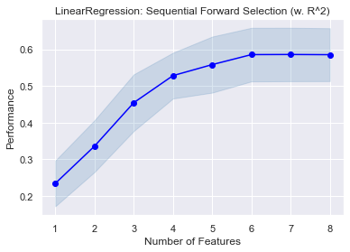

```python
# Find feature selection using LinearRegression - for Original data

linearReg = LinearRegression()
linearRegSuggestedFeatures = forwardFeatureSuggestor(linearReg, 'LinearRegression', originalFeatureCount, X_Train, Y_Train, folds)
linearRegSuggestedFeatures
```

```
array([('cement', 'slag', 'ash', 'water', 'superplastic', 'coarseagg', 'age')],
      dtype=object)
```

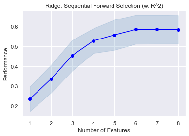

```python
# Find feature selection using Ridge - for Original data

ridge = Ridge(alpha=0.3)
ridgeSuggestedFeatures = forwardFeatureSuggestor(ridge, 'Ridge', originalFeatureCount, X_Train, Y_Train, folds)
ridgeSuggestedFeatures
```

```
array([('cement', 'slag', 'ash', 'water', 'superplastic', 'coarseagg', 'age')],
      dtype=object)
```

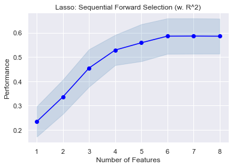

```python
# Find feature selection using Lasso - for Original data

lasso = Lasso(alpha=0.3)
lassoSuggestedFeatures = forwardFeatureSuggestor(lasso, 'Lasso', originalFeatureCount, X_Train, Y_Train, folds)
lassoSuggestedFeatures
```

```
array([('cement', 'slag', 'ash', 'water', 'superplastic', 'coarseagg', 'fineagg', 'age')],
      dtype=object)
```

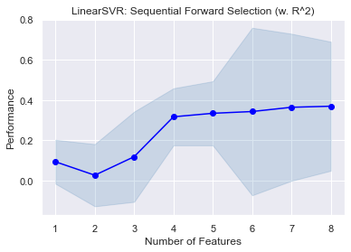

```python
# Find feature selection using LinearSVR - for Original data

linearSVR = LinearSVR(random_state=random)
linearSVRSuggestedFeatures = forwardFeatureSuggestor(linearSVR, 'LinearSVR', originalFeatureCount, X_Train, Y_Train, folds)
linearSVRSuggestedFeatures
```

### Feature 'Fine Aggregate (fineagg)' is not included in suggested features by majority of algorithms above, so lets drop it.

```python
X.drop(columns='fineagg', inplace=True)
X.head()
```

|  | cement | slag | ash | water | superplastic | coarseagg | age |
| --- | --- | --- | --- | --- | --- | --- | --- |
| 0 | 141.3 | 212.0 | 0.0 | 203.5 | 0.0 | 971.8 | 28 |
| 1 | 168.9 | 42.2 | 124.3 | 158.3 | 10.8 | 1080.8 | 14 |
| 2 | 250.0 | 0.0 | 95.7 | 187.4 | 5.5 | 956.9 | 28 |
| 3 | 266.0 | 114.0 | 0.0 | 228.0 | 0.0 | 932.0 | 28 |
| 4 | 154.8 | 183.4 | 0.0 | 193.3 | 9.1 | 1047.4 | 28 |

```python
# New Features using PolynomialFeatures - after making a decision to drop features.

originalFeatureCount = X.shape[1]
print('No. of independent features before PolynomialFeatures:', originalFeatureCount)
poly = preprocessing.PolynomialFeatures(degree=2, include_bias=False)
X_Poly = poly.fit_transform(X)

polynomialFeatureCount = X_Poly.shape[1]
print('No. of independent features after PolynomialFeatures:', polynomialFeatureCount)
```

```
No. of independent features before PolynomialFeatures: 7
No. of independent features after PolynomialFeatures: 35
```

### Let's decide whether to use polynomial features or not

#### Steps

- Determine performance of models on Original data
- Determine performance of models on Polynomial data
- Compare performances and make decision

```python
# Split data again after dropping a feature

X_Train, X_Test, Y_Train, Y_Test = train_test_split(X, Y, test_size=0.3, random_state=random)
```

```python
def findScoreAndCoeffs (model, modelName, x_train, y_train, x_test, y_test, printCoeffs=True):
    model.fit(x_train, y_train)
    print(modelName, " Model: ")
    print()
    print("Training Score = ", model.score(x_train, y_train), " Testing Score = ", model.score(x_test, y_test))
    print()
    if(printCoeffs):
        for idx, col_name in enumerate(x_train.columns):
            if(modelName == "Lasso Regression" or modelName == 'Linear SVR Regression'):
                print("The coefficient for {} is {}".format(col_name, model.coef_[idx]))
            else:
                print("The coefficient for {} is {}".format(col_name, model.coef_[0][idx]))
```

```python
# Find score and coefficients for Linear Regression model

findScoreAndCoeffs(linearReg, 'Linear Regression', X_Train, Y_Train, X_Test, Y_Test)
```

```
Linear Regression  Model:

Training Score =  0.610686974064802  Testing Score =  0.620488675625793

The coefficient for cement is 0.10761736528749367
The coefficient for slag is 0.09015105047869405
The coefficient for ash is 0.065594274262238
The coefficient for water is -0.20001117143344646
The coefficient for superplastic is 0.31611496683761037
The coefficient for coarseagg is 0.006574755226401579
The coefficient for age is 0.1117443782140754
```

```python
# Find score and coefficients for Ridge Regression model

findScoreAndCoeffs(ridge, 'Ridge Regression', X_Train, Y_Train, X_Test, Y_Test)
```

```
Ridge Regression  Model:

Training Score =  0.6106869740609211  Testing Score =  0.6204888206283374

The coefficient for cement is 0.10761746061481203
The coefficient for slag is 0.09015117555455376
The coefficient for ash is 0.06559456405669124
The coefficient for water is -0.20001264916797182
The coefficient for superplastic is 0.31610543295367
The coefficient for coarseagg is 0.006574542184733795
The coefficient for age is 0.11174436196931681
```

```python
# Find score and coefficients for Lasso Regression model

findScoreAndCoeffs(lasso, 'Lasso Regression', X_Train, Y_Train, X_Test, Y_Test)
```

```
Lasso Regression  Model:

Training Score =  0.6106694154885057  Testing Score =  0.6207887103050982

The coefficient for cement is 0.10771277805956829
The coefficient for slag is 0.09026537897608365
The coefficient for ash is 0.06600211128552076
The coefficient for water is -0.20290764738797434
The coefficient for superplastic is 0.29645450073301255
The coefficient for coarseagg is 0.006028728838974858
The coefficient for age is 0.11161771651908606
```

```python
# Find score and coefficients for Linear SVR Regression model

findScoreAndCoeffs(linearSVR, 'Linear SVR Regression', X_Train, Y_Train, X_Test, Y_Test)
```

```
Linear SVR Regression  Model:

Training Score =  0.6012544440255693  Testing Score =  0.6071798318928556

The coefficient for cement is 0.10246590137028476
The coefficient for slag is 0.09113616537100926
The coefficient for ash is 0.05940748318215453
The coefficient for water is -0.15517704935086254
The coefficient for superplastic is 0.41612386801463247
The coefficient for coarseagg is 0.016992706385845165
The coefficient for age is 0.12973076988889268
```

```python
# Split polynomial data.

X_Train_Poly, X_Test_Poly, Y_Train_Poly, Y_Test_Poly = train_test_split(X_Poly, Y, test_size=0.3, random_state=random)
```

```python
# Find score for Linear Regression model for Polynomial data

findScoreAndCoeffs(linearReg, 'Linear Regression', X_Train_Poly, Y_Train_Poly, X_Test_Poly, Y_Test_Poly, False)
```

```
Linear Regression  Model:

Training Score =  0.8022876530964875  Testing Score =  0.7724924777248504
```

```python
# Find score for Ridge Regression model for Polynomial data

findScoreAndCoeffs(ridge, 'Ridge Regression', X_Train_Poly, Y_Train_Poly, X_Test_Poly, Y_Test_Poly, False)
```

```
Ridge Regression  Model:

Training Score =  0.8022863091344445  Testing Score =  0.7725490534158364
```

```python
# Find score for Lasso Regression model for Polynomial data

findScoreAndCoeffs(lasso, 'Lasso Regression', X_Train_Poly, Y_Train_Poly, X_Test_Poly, Y_Test_Poly, False)
```

```
Lasso Regression  Model:

Training Score =  0.7918241563445902  Testing Score =  0.7803754931825689
```

```python
# Find score for Linear SVR Regression model for Polynomial data

findScoreAndCoeffs(linearSVR, 'Linear SVR Regression', X_Train_Poly, Y_Train_Poly, X_Test_Poly, Y_Test_Poly, False)
```

```
Linear SVR Regression  Model:

Training Score =  0.7476998492906285  Testing Score =  0.6941435789588035
```

## Using polynomial features has increased performance of the models, so let's use the polynomial features for final model as well.

### Thus, the model using polynomial features will be a higer degree complexity model

## Let's rebuild the data splits and keep the Test data aside for testing the models.

```python
# Split Original data

X_Train, X_Test, Y_Train, Y_Test = train_test_split(X, Y, test_size=0.3, random_state=random)

# Split Polynomial data

X_Train_Poly, X_Test_Poly, Y_Train_Poly, Y_Test_Poly = train_test_split(X_Poly, Y, test_size=0.3, random_state=random)
```

# Deliverable – 2

## Creating the model and tuning the model

# K-Fold Cross Validation

### Following algorithms to be used

- Simple Linear Regression
- Ridge Regression
- Lasso Regression
- Support Vector Machines (SVM) - LinearSVR

```python
# create KFold object for verification

kfold = KFold(n_splits=folds, random_state=random)
```

```python
# Dataframe to store KFold validation results

kFoldResults = pd.DataFrame(columns=['Regressor', 'KFold Max Accuracy %', 'KFold Mean Accuracy %', ' (+-) Deviation %', 'Features',
                                     'Has Polynomial Features', 'Estimator'])
```

```python
def collectScoreWithKFold(model, modelName, x_train, y_train, polyData):
    result = cross_validate(estimator=model, X= x_train, y=y_train, cv=kfold, return_estimator=True)
    resultDF = pd.DataFrame(result)
    maxScore = resultDF['test_score'].max()
    meanScore = resultDF['test_score'].mean()
    stdScore = resultDF['test_score'].std()
    estimator = list(resultDF[resultDF['test_score']==maxScore]['estimator'])[0]
    #print(resultDF)
    resultFrame = pd.Series([modelName, maxScore*100, meanScore*100, stdScore*100, x_train.shape[1], polyData, estimator], index=kFoldResults.columns)
    return resultFrame
```

```python
# Evaluate Simple linear regression with KFold on Original data

resultFrame = collectScoreWithKFold(linearReg, "Linear Regression", X_Train, Y_Train, "no")
kFoldResults = kFoldResults.append(resultFrame, ignore_index=True)
resultFrame
```

```
Regressor                                                  Linear Regression
KFold Max Accuracy %                                                   72.71
KFold Mean Accuracy %                                                58.5996
 (+-) Deviation %                                                    7.68192
Features                                                                   7
Has Polynomial Features                                                   no
Estimator                  LinearRegression(copy_X=True, fit_intercept=Tr...
dtype: object
```

```python
# Evaluate Ridge regression with KFold on Original data

resultFrame = collectScoreWithKFold(ridge, "Ridge Regression", X_Train, Y_Train, "no")
kFoldResults = kFoldResults.append(resultFrame, ignore_index=True)
resultFrame
```

```
Regressor                                                   Ridge Regression
KFold Max Accuracy %                                                   72.71
KFold Mean Accuracy %                                                58.5996
 (+-) Deviation %                                                    7.68192
Features                                                                   7
Has Polynomial Features                                                   no
Estimator                  Ridge(alpha=0.3, copy_X=True, fit_intercept=Tr...
dtype: object
```

```python
# Evaluate Lasso regression with KFold on Original data

resultFrame = collectScoreWithKFold(lasso, "Lasso Regression", X_Train, Y_Train, "no")
kFoldResults = kFoldResults.append(resultFrame, ignore_index=True)
resultFrame
```

```
Regressor                                                   Lasso Regression
KFold Max Accuracy %                                                 72.6693
KFold Mean Accuracy %                                                58.6036
 (+-) Deviation %                                                    7.66113
Features                                                                   7
Has Polynomial Features                                                   no
Estimator                  Lasso(alpha=0.3, copy_X=True, fit_intercept=Tr...
dtype: object
```

```python
# Evaluate LinearSVR regression with KFold on Original data

resultFrame = collectScoreWithKFold(linearSVR, "Linear SVR Regression", X_Train, Y_Train, "no")
kFoldResults = kFoldResults.append(resultFrame, ignore_index=True)
resultFrame
```

```
Regressor                                              Linear SVR Regression
KFold Max Accuracy %                                                 58.0407
KFold Mean Accuracy %                                                36.4171
 (+-) Deviation %                                                    38.5066
Features                                                                   7
Has Polynomial Features                                                   no
Estimator                  LinearSVR(C=1.0, dual=True, epsilon=0.0, fit_i...
dtype: object
```

```python
# Evaluate Simple linear regression with KFold on Polynomial data

resultFrame = collectScoreWithKFold(linearReg, "Linear Regression", X_Train_Poly, Y_Train_Poly, "yes")
kFoldResults = kFoldResults.append(resultFrame, ignore_index=True)
resultFrame
```

```
Regressor                                                  Linear Regression
KFold Max Accuracy %                                                 84.9914
KFold Mean Accuracy %                                                75.7001
 (+-) Deviation %                                                    5.26018
Features                                                                  35
Has Polynomial Features                                                  yes
Estimator                  LinearRegression(copy_X=True, fit_intercept=Tr...
dtype: object
```

```python
# Evaluate Ridge regression with KFold on Original data

resultFrame = collectScoreWithKFold(ridge, "Ridge Regression", X_Train_Poly, Y_Train_Poly, "yes")
kFoldResults = kFoldResults.append(resultFrame, ignore_index=True)
resultFrame
```

```
Regressor                                                   Ridge Regression
KFold Max Accuracy %                                                 85.0116
KFold Mean Accuracy %                                                75.7068
 (+-) Deviation %                                                    5.26841
Features                                                                  35
Has Polynomial Features                                                  yes
Estimator                  Ridge(alpha=0.3, copy_X=True, fit_intercept=Tr...
dtype: object
```

```python
# Evaluate Lasso regression with KFold on Original data

resultFrame = collectScoreWithKFold(lasso, "Lasso Regression", X_Train_Poly, Y_Train_Poly, "yes")
kFoldResults = kFoldResults.append(resultFrame, ignore_index=True)
resultFrame
```

```
Regressor                                                   Lasso Regression
KFold Max Accuracy %                                                 84.7974
KFold Mean Accuracy %                                                74.6968
 (+-) Deviation %                                                    5.85919
Features                                                                  35
Has Polynomial Features                                                  yes
Estimator                  Lasso(alpha=0.3, copy_X=True, fit_intercept=Tr...
dtype: object
```

```python
# Evaluate LinearSVR regression with KFold on Original data

resultFrame = collectScoreWithKFold(linearSVR, "Linear SVR Regression", X_Train_Poly, Y_Train_Poly, "yes")
kFoldResults = kFoldResults.append(resultFrame, ignore_index=True)
resultFrame
```

```
Regressor                                              Linear SVR Regression
KFold Max Accuracy %                                                 79.1203
KFold Mean Accuracy %                                                65.1561
 (+-) Deviation %                                                    11.7949
Features                                                                  35
Has Polynomial Features                                                  yes
Estimator                  LinearSVR(C=1.0, dual=True, epsilon=0.0, fit_i...
dtype: object
```

## KFold cross validation result

```python
kFoldResults
```

|  | Regressor | KFold Max Accuracy % | KFold Mean Accuracy % | (+-) Deviation % | Features | Has Polynomial Features | Estimator |
| --- | --- | --- | --- | --- | --- | --- | --- |
| 0 | Linear Regression | 72.709969 | 58.599614 | 7.681925 | 7 | no | LinearRegression(copy_X=True, fit_intercept=Tr... |
| 1 | Ridge Regression | 72.709960 | 58.599619 | 7.681918 | 7 | no | Ridge(alpha=0.3, copy_X=True, fit_intercept=Tr... |
| 2 | Lasso Regression | 72.669304 | 58.603573 | 7.661132 | 7 | no | Lasso(alpha=0.3, copy_X=True, fit_intercept=Tr... |
| 3 | Linear SVR Regression | 58.040750 | 36.417128 | 38.506563 | 7 | no | LinearSVR(C=1.0, dual=True, epsilon=0.0, fit_i... |
| 4 | Linear Regression | 84.991426 | 75.700131 | 5.260175 | 35 | yes | LinearRegression(copy_X=True, fit_intercept=Tr... |
| 5 | Ridge Regression | 85.011558 | 75.706836 | 5.268406 | 35 | yes | Ridge(alpha=0.3, copy_X=True, fit_intercept=Tr... |
| 6 | Lasso Regression | 84.797374 | 74.696801 | 5.859190 | 35 | yes | Lasso(alpha=0.3, copy_X=True, fit_intercept=Tr... |
| 7 | Linear SVR Regression | 79.120322 | 65.156126 | 11.794916 | 35 | yes | LinearSVR(C=1.0, dual=True, epsilon=0.0, fit_i... |

### Observation - Including polynomial features increases accuracy and reduces deviation.

## Let's find the best model and validate on Test data based on KFold results

```python
kFoldResults.groupby(by=['Features']).agg({'KFold Max Accuracy %' : np.max}).reset_index()
```

|  | Features | KFold Max Accuracy % |
| --- | --- | --- |
| 0 | 7 | 72.709969 |
| 1 | 35 | 85.011558 |

```python
accArrayKFold = np.array(kFoldResults.groupby(by=['Features']).agg({'KFold Max Accuracy %' : np.max}))
accArrayKFold
```

```
array([[72.7099686 ],
       [85.01155842]])
```

```python
# Find best model for Original features

bestResultKFold = kFoldResults[(kFoldResults['Features'] == 7) & (kFoldResults['KFold Max Accuracy %'] == accArrayKFold.item(0))]
bestResultKFold
```

|  | Regressor | KFold Max Accuracy % | KFold Mean Accuracy % | (+-) Deviation % | Features | Has Polynomial Features | Estimator |
| --- | --- | --- | --- | --- | --- | --- | --- |
| 0 | Linear Regression | 72.709969 | 58.599614 | 7.681925 | 7 | no | LinearRegression(copy_X=True, fit_intercept=Tr... |

```python
bestRegressorKFold = list(bestResultKFold['Regressor'])[0]
bestRegressorKFold
```

```
'Linear Regression'
```

```python
modelParamsKFold = str(list(bestResultKFold['Estimator'])[0]).replace(" ","")
modelParamsKFold = modelParamsKFold.replace('\n', '')

if(bestRegressorKFold == 'Linear Regression'):
    modelParamsKFold = modelParamsKFold.replace("LinearRegression(", '{"')
elif(bestRegressorKFold == 'Ridge Regression'):
    modelParamsKFold = modelParamsKFold.replace("Ridge(", '{"')
elif(bestRegressorKFold == 'Lasso Regression'):
    modelParamsKFold = modelParamsKFold.replace("Lasso(", '{"')
elif(bestRegressorKFold == 'Linear SVR Regression'):
    modelParamsKFold = modelParamsKFold.replace("LinearSVR(", '{"')

modelParamsKFold = modelParamsKFold.replace(")", '"}').replace("=", '":"').replace(",",'", "')

#print(modelParamsKFold)
modelParamsKFold = json.loads(modelParamsKFold)
modelParamsKFold
```

```
{'copy_X': 'True',
 'fit_intercept': 'True',
 'n_jobs': 'None',
 'normalize': 'False'}
```

```python
modelKFold = None

if(bestRegressorKFold == 'Linear Regression'):
    modelKFold = LinearRegression()
elif(bestRegressorKFold == 'Ridge Regression'):
    modelKFold = Ridge()
elif(bestRegressorKFold == 'Lasso Regression'):
    modelKFold = Lasso()
elif(bestRegressorKFold == 'Linear SVR Regression'):
    modelKFold = LinearSVR()


modelKFold.fit(X_Train, Y_Train)
print(bestRegressorKFold, " Accuracy on Training Set with Original features", modelKFold.score(X_Train, Y_Train) * 100, "%")
print(bestRegressorKFold, " Accuracy on Test Set with Original features    ", modelKFold.score(X_Test, Y_Test) * 100, "%")
```

```
Linear Regression  Accuracy on Training Set with Original features 61.0686974064802 %
Linear Regression  Accuracy on Test Set with Original features     62.048867562579304 %
```

```python
# Find best model for Polynomial features

bestResultKFoldPoly = kFoldResults[(kFoldResults['Features'] == 35) & (kFoldResults['KFold Max Accuracy %'] == accArrayKFold.item(1))]
bestResultKFoldPoly
```

|  | Regressor | KFold Max Accuracy % | KFold Mean Accuracy % | (+-) Deviation % | Features | Has Polynomial Features | Estimator |
| --- | --- | --- | --- | --- | --- | --- | --- |
| 5 | Ridge Regression | 85.011558 | 75.706836 | 5.268406 | 35 | yes | Ridge(alpha=0.3, copy_X=True, fit_intercept=Tr... |

```python
bestRegressorKFoldPoly = list(bestResultKFoldPoly['Regressor'])[0]
bestRegressorKFoldPoly
```

```
'Ridge Regression'
```

```python
modelParamsKFoldPoly = str(list(bestResultKFoldPoly['Estimator'])[0]).replace(" ","")
modelParamsKFoldPoly = modelParamsKFoldPoly.replace('\n', '')

if(bestRegressorKFoldPoly == 'Linear Regression'):
    modelParamsKFoldPoly = modelParamsKFoldPoly.replace("LinearRegression(", '{"')
elif(bestRegressorKFoldPoly == 'Ridge Regression'):
    modelParamsKFoldPoly = modelParamsKFoldPoly.replace("Ridge(", '{"')
elif(bestRegressorKFoldPoly == 'Lasso Regression'):
    modelParamsKFoldPoly = modelParamsKFoldPoly.replace("Lasso(", '{"')
elif(bestRegressorKFoldPoly == 'Linear SVR Regression'):
    modelParamsKFoldPoly = modelParamsKFoldPoly.replace("LinearSVR(", '{"')

modelParamsKFoldPoly = modelParamsKFoldPoly.replace(")", '"}').replace("=", '":"').replace(",",'","')

#print(modelParamsKFoldPoly)
modelParamsKFoldPoly = json.loads(modelParamsKFoldPoly)
modelParamsKFoldPoly
```

```
{'alpha': '0.3',
 'copy_X': 'True',
 'fit_intercept': 'True',
 'max_iter': 'None',
 'normalize': 'False',
 'random_state': 'None',
 'solver': "'auto'",
 'tol': '0.001'}
```

```python
modelKFoldPoly = None

if(bestRegressorKFoldPoly == 'Linear Regression'):
    modelKFoldPoly = LinearRegression()
elif(bestRegressorKFoldPoly == 'Ridge Regression'):
    modelKFoldPoly = Ridge()
elif(bestRegressorKFoldPoly == 'Lasso Regression'):
    modelKFoldPoly = Lasso()
elif(bestRegressorKFoldPoly == 'Linear SVR Regression'):
    modelKFoldPoly = LinearSVR()


modelKFoldPoly.fit(X_Train, Y_Train)
print(bestRegressorKFoldPoly, " Accuracy on Training Set with Polynomial features", modelKFoldPoly.score(X_Train, Y_Train) * 100, "%")
print(bestRegressorKFoldPoly, " Accuracy on Test Set with Polynomial features    ", modelKFoldPoly.score(X_Test, Y_Test) * 100, "%")
```

```
Ridge Regression  Accuracy on Training Set with Polynomial features 61.068697402168645 %
Ridge Regression  Accuracy on Test Set with Polynomial features     62.04891588897765 %
```

# Hyperparameter Tuning

### Algorithms to be used

- Grid Search - Providing small param space for GridSearchCV as it takes lot of time to complete all iterations.
- Random Search - Providing max possible param space for RandomSearchCV as it is faster and try hit parameters at random.

```python
# Dataframe to store Hyperparameter Tuning results

hyperResults = pd.DataFrame(columns=['Regressor', 'SearchCV', 'Accuracy %', ' (+-) Deviation %', 'Features',
                                     'Has Polynomial Features', 'Param Space Size', 'Best Params'])
```

```python
def tuneHyperParams (model, modelName, x_train, y_train, params, polyData, searchAlgo, paramSpaceSize):
    if(searchAlgo == 'GridSearchCV'):
        modelCV = GridSearchCV(estimator=model, param_grid=params, cv=folds)
    elif(searchAlgo == 'RandomizedSearchCV'):
        modelCV = RandomizedSearchCV(estimator=model, param_distributions=params, cv=folds, n_iter=1000)

    modelCV.fit(x_train, y_train)
    modelCVResult = pd.DataFrame(modelCV.cv_results_)
    modelCVMaxScore = modelCVResult['mean_test_score'].max()
    modelCVDeviation = np.array(modelCVResult[modelCVResult['mean_test_score'] == modelCVMaxScore]['std_test_score'])
    resultFrame = pd.Series([modelName, searchAlgo, modelCVMaxScore*100, modelCVDeviation[0]*100, x_train.shape[1],
                             polyData, paramSpaceSize, modelCV.best_params_], index=hyperResults.columns)
    return resultFrame
```

```python
# Initialize Linear Regression Parameter grid and Model for GridSearchCV

linearRegParamsGS = {
    'fit_intercept' : (True, False),
    'normalize' : (True, False)
}

linearReg = LinearRegression()

linearRegParamsGSSpaceSize = 4
```

```python
# Initialize Ridge Regression Parameter grid and Model for GridSearchCV

ridgeParamsGS = {
    'alpha' : (0.5, 1.0),
    'fit_intercept' : (True, False),
    'normalize' : (True, False),
    'tol' : (0.5, 1.0),
    'solver' : ('auto', 'saga')
}

ridge = Ridge(random_state=random)

ridgeParamsGSSpaceSize = 32
```

```python
# Initialize Lasso Regression Parameter grid and Model for GridSearchCV

lassoParamsGS = {
    'alpha' : (0.5, 1.0),
    'fit_intercept' : (True, False),
    'normalize' : (True, False),
    'precompute' : (True, False),
    'tol' : (0.5, 1.0),
    'warm_start' : (True, False),
    'positive' : (True, False),
}

lasso = Lasso(random_state=random)

lassoParamsGSSpaceSize = 128
```

```python
# Initialize Linear SVR Regression Parameter grid and Model for GridSearchCV

linearSVRParamsGS = {
    'loss': ('epsilon_insensitive', 'squared_epsilon_insensitive'),
    'fit_intercept' : (True, False),
    'intercept_scaling' : (0.5, 1.0),
    'dual' : (True, False)
}

# Reinitiate model
linearSVR = LinearSVR(random_state=random)

linearSVRParamsGSSpaceSize = 16
```

```python
# Hyperparameter tuning for Linear Regression for Original Data

resultFrame = tuneHyperParams(linearReg, 'Linear Regression', X_Train, Y_Train, linearRegParamsGS, "no",
                              'GridSearchCV', linearRegParamsGSSpaceSize)
hyperResults = hyperResults.append(resultFrame, ignore_index=True)
resultFrame
```

```
Regressor                                           Linear Regression
SearchCV                                                 GridSearchCV
Accuracy %                                                    58.5996
 (+-) Deviation %                                             7.28771
Features                                                            7
Has Polynomial Features                                            no
Param Space Size                                                    4
Best Params                {'fit_intercept': True, 'normalize': True}
dtype: object
```

```python
# Hyperparameter tuning for Ridge Regression for Original Data

resultFrame = tuneHyperParams(ridge, 'Ridge Regression', X_Train, Y_Train, ridgeParamsGS, "no",
                              'GridSearchCV', ridgeParamsGSSpaceSize)
hyperResults = hyperResults.append(resultFrame, ignore_index=True)
resultFrame
```

```
Regressor                                                   Ridge Regression
SearchCV                                                        GridSearchCV
Accuracy %                                                           58.5996
 (+-) Deviation %                                                    7.28769
Features                                                                   7
Has Polynomial Features                                                   no
Param Space Size                                                          32
Best Params                {'alpha': 1.0, 'fit_intercept': True, 'normali...
dtype: object
```

```python
# Hyperparameter tuning for Lasso Regression for Original Data

resultFrame = tuneHyperParams(lasso, 'Lasso Regression', X_Train, Y_Train, lassoParamsGS, "no",
                              'GridSearchCV', lassoParamsGSSpaceSize)
hyperResults = hyperResults.append(resultFrame, ignore_index=True)
resultFrame
```

```
Regressor                                                   Lasso Regression
SearchCV                                                        GridSearchCV
Accuracy %                                                           58.1703
 (+-) Deviation %                                                    6.84329
Features                                                                   7
Has Polynomial Features                                                   no
Param Space Size                                                         128
Best Params                {'alpha': 0.5, 'fit_intercept': True, 'normali...
dtype: object
```

```python
# Hyperparameter tuning for Linear SVR Regression for Original Data

resultFrame = tuneHyperParams(linearSVR, 'Linear SVR Regression', X_Train, Y_Train, linearSVRParamsGS, "no",
                              'GridSearchCV', linearSVRParamsGSSpaceSize)
hyperResults = hyperResults.append(resultFrame, ignore_index=True)
resultFrame
```

```
Regressor                                              Linear SVR Regression
SearchCV                                                        GridSearchCV
Accuracy %                                                           58.4505
 (+-) Deviation %                                                     7.1784
Features                                                                   7
Has Polynomial Features                                                   no
Param Space Size                                                          16
Best Params                {'dual': False, 'fit_intercept': True, 'interc...
dtype: object
```

```python
# Hyperparameter tuning for Linear Regression for Polynomial Data

resultFrame = tuneHyperParams(linearReg, 'Linear Regression', X_Train_Poly, Y_Train_Poly, linearRegParamsGS, "yes",
                              'GridSearchCV', linearRegParamsGSSpaceSize)
hyperResults = hyperResults.append(resultFrame, ignore_index=True)
resultFrame
```

```
Regressor                                            Linear Regression
SearchCV                                                  GridSearchCV
Accuracy %                                                     75.7001
 (+-) Deviation %                                              4.99024
Features                                                            35
Has Polynomial Features                                            yes
Param Space Size                                                     4
Best Params                {'fit_intercept': True, 'normalize': False}
dtype: object
```

```python
# Hyperparameter tuning for Ridge Regression for Polynomial Data

resultFrame = tuneHyperParams(ridge, 'Ridge Regression', X_Train_Poly, Y_Train_Poly, ridgeParamsGS, "yes",
                              'GridSearchCV', ridgeParamsGSSpaceSize)
hyperResults = hyperResults.append(resultFrame, ignore_index=True)
resultFrame
```

```
Regressor                                                   Ridge Regression
SearchCV                                                        GridSearchCV
Accuracy %                                                           75.7187
 (+-) Deviation %                                                    5.01419
Features                                                                  35
Has Polynomial Features                                                  yes
Param Space Size                                                          32
Best Params                {'alpha': 1.0, 'fit_intercept': True, 'normali...
dtype: object
```

```python
# Hyperparameter tuning for Lasso Regression for Polynomial Data

resultFrame = tuneHyperParams(lasso, 'Lasso Regression', X_Train_Poly, Y_Train_Poly, lassoParamsGS, "yes",
                              'GridSearchCV', lassoParamsGSSpaceSize)
hyperResults = hyperResults.append(resultFrame, ignore_index=True)
resultFrame
```

```
Regressor                                                   Lasso Regression
SearchCV                                                        GridSearchCV
Accuracy %                                                           70.7276
 (+-) Deviation %                                                    6.18945
Features                                                                  35
Has Polynomial Features                                                  yes
Param Space Size                                                         128
Best Params                {'alpha': 1.0, 'fit_intercept': True, 'normali...
dtype: object
```

```python
# Hyperparameter tuning for Linear SVR Regression for Polynomial Data

resultFrame = tuneHyperParams(linearSVR, 'Linear SVR Regression', X_Train_Poly, Y_Train_Poly, linearSVRParamsGS, "yes",
                              'GridSearchCV', linearSVRParamsGSSpaceSize)
hyperResults = hyperResults.append(resultFrame, ignore_index=True)
resultFrame
```

```
Regressor                                              Linear SVR Regression
SearchCV                                                        GridSearchCV
Accuracy %                                                           71.7321
 (+-) Deviation %                                                    5.55601
Features                                                                  35
Has Polynomial Features                                                  yes
Param Space Size                                                          16
Best Params                {'dual': False, 'fit_intercept': True, 'interc...
dtype: object
```

```python
# Initialize Linear Regression Parameter grid and Model for RandomizedSearchCV

linearRegParamsRS = {
    'fit_intercept' : (True, False),
    'normalize' : (True, False)
}

linearReg = LinearRegression()

linearRegParamsRSSpaceSize = 4
```

```python
# Initialize Ridge Regression Parameter grid and Model for RandomizedSearchCV

ridgeParamsRS = {
    'alpha' : list(np.arange(0.01, 1.01, 0.01)),
    'fit_intercept' : (True, False),
    'normalize' : (True, False),
    'tol' : list(np.arange(0.001, 1.001, 0.001)),
    'solver': ('auto', 'svd', 'cholesky', 'lsqr', 'sparse_cg', 'sag', 'saga')
}

ridge = Ridge(random_state=random)

ridgeParamsRSSpaceSize = 2800000
```

```python
# Initialize Lasso Regression Parameter grid and Model for RandomizedSearchCV

lassoParamsRS = {
    'alpha' : list(np.arange(0.01, 1.01, 0.01)),
    'fit_intercept' : (True, False),
    'normalize' : (True, False),
    'precompute' : (True, False),
    'tol' : list(np.arange(0.0001, 1.0001, 0.0001)),
    'warm_start' : (True, False),
    'positive' : (True, False),
}

lasso = Lasso(random_state=random)

lassoParamsRSSpaceSize = 32000000
```

```python
# Initialize Linear SVR Regression Parameter grid and Model for RandomizedSearchCV

linearSVRParamsRS = {
    'tol' : list(np.arange(0.0001, 1.0001, 0.0001)),
    'C' : list(np.arange(0.01, 1.01, 0.01)),
    'loss': ('epsilon_insensitive', 'squared_epsilon_insensitive'),
    'fit_intercept' : (True, False),
    'intercept_scaling' : list(np.arange(0.01, 1.01, 0.01)),
    'dual' : (True, False)
}

# Reinitiate model
linearSVR = LinearSVR(random_state=random)

linearSVRParamsRSSpaceSize = 800000000
```

```python
# Hyperparameter tuning for Linear Regression for Original Data

resultFrame = tuneHyperParams(linearReg, 'Linear Regression', X_Train, Y_Train, linearRegParamsRS, "no",
                              'RandomizedSearchCV', linearRegParamsRSSpaceSize)
hyperResults = hyperResults.append(resultFrame, ignore_index=True)
resultFrame
```

```
Regressor                                           Linear Regression
SearchCV                                           RandomizedSearchCV
Accuracy %                                                    58.5996
 (+-) Deviation %                                             7.28771
Features                                                            7
Has Polynomial Features                                            no
Param Space Size                                                    4
Best Params                {'normalize': True, 'fit_intercept': True}
dtype: object
```

```python
# Hyperparameter tuning for Ridge Regression for Original Data

resultFrame = tuneHyperParams(ridge, 'Ridge Regression', X_Train, Y_Train, ridgeParamsRS, "no",
                              'RandomizedSearchCV', ridgeParamsRSSpaceSize)
hyperResults = hyperResults.append(resultFrame, ignore_index=True)
resultFrame
```

```
Regressor                                                   Ridge Regression
SearchCV                                                  RandomizedSearchCV
Accuracy %                                                            58.601
 (+-) Deviation %                                                    7.10637
Features                                                                   7
Has Polynomial Features                                                   no
Param Space Size                                                     2800000
Best Params                {'tol': 0.635, 'solver': 'cholesky', 'normaliz...
dtype: object
```

```python
# Hyperparameter tuning for Lasso Regression for Original Data

resultFrame = tuneHyperParams(lasso, 'Lasso Regression', X_Train, Y_Train, lassoParamsRS, "no",
                              'RandomizedSearchCV', lassoParamsRSSpaceSize)
hyperResults = hyperResults.append(resultFrame, ignore_index=True)
resultFrame
```

```
Regressor                                                   Lasso Regression
SearchCV                                                  RandomizedSearchCV
Accuracy %                                                           58.6037
 (+-) Deviation %                                                    7.25753
Features                                                                   7
Has Polynomial Features                                                   no
Param Space Size                                                    32000000
Best Params                {'warm_start': True, 'tol': 0.1558999999999999...
dtype: object
```

```python
# Hyperparameter tuning for Linear SVR Regression for Original Data

resultFrame = tuneHyperParams(linearSVR, 'Linear SVR Regression', X_Train, Y_Train, linearSVRParamsRS, "no",
                              'RandomizedSearchCV', linearSVRParamsRSSpaceSize)
hyperResults = hyperResults.append(resultFrame, ignore_index=True)
resultFrame
```

```
Regressor                                              Linear SVR Regression
SearchCV                                                  RandomizedSearchCV
Accuracy %                                                           57.9795
 (+-) Deviation %                                                    7.34875
Features                                                                   7
Has Polynomial Features                                                   no
Param Space Size                                                   800000000
Best Params                {'tol': 0.0013000000000000002, 'loss': 'square...
dtype: object
```

```python
# Hyperparameter tuning for Linear Regression for Polynomial Data

resultFrame = tuneHyperParams(linearReg, 'Linear Regression', X_Train_Poly, Y_Train_Poly, linearRegParamsRS, "yes",
                              'RandomizedSearchCV', linearRegParamsRSSpaceSize)
hyperResults = hyperResults.append(resultFrame, ignore_index=True)
resultFrame
```

```
Regressor                                            Linear Regression
SearchCV                                            RandomizedSearchCV
Accuracy %                                                     75.7001
 (+-) Deviation %                                              4.99024
Features                                                            35
Has Polynomial Features                                            yes
Param Space Size                                                     4
Best Params                {'normalize': False, 'fit_intercept': True}
dtype: object
```

```python
# Hyperparameter tuning for Ridge Regression for Polynomial Data

resultFrame = tuneHyperParams(ridge, 'Ridge Regression', X_Train_Poly, Y_Train_Poly, ridgeParamsRS, "yes",
                              'RandomizedSearchCV', ridgeParamsRSSpaceSize)
hyperResults = hyperResults.append(resultFrame, ignore_index=True)
resultFrame
```

```
Regressor                                                   Ridge Regression
SearchCV                                                  RandomizedSearchCV
Accuracy %                                                           75.7187
 (+-) Deviation %                                                    5.01419
Features                                                                  35
Has Polynomial Features                                                  yes
Param Space Size                                                     2800000
Best Params                {'tol': 0.598, 'solver': 'svd', 'normalize': F...
dtype: object
```

```python
# Hyperparameter tuning for Lasso Regression for Polynomial Data

resultFrame = tuneHyperParams(lasso, 'Lasso Regression', X_Train_Poly, Y_Train_Poly, lassoParamsRS, "yes",
                              'RandomizedSearchCV', lassoParamsRSSpaceSize)
hyperResults = hyperResults.append(resultFrame, ignore_index=True)
resultFrame
```

```
Regressor                                                   Lasso Regression
SearchCV                                                  RandomizedSearchCV
Accuracy %                                                           74.9844
 (+-) Deviation %                                                    5.15874
Features                                                                  35
Has Polynomial Features                                                  yes
Param Space Size                                                    32000000
Best Params                {'warm_start': True, 'tol': 0.1072, 'precomput...
dtype: object
```

```python
# Hyperparameter tuning for Linear SVR Regression for Polynomial Data

resultFrame = tuneHyperParams(linearSVR, 'Linear SVR Regression', X_Train_Poly, Y_Train_Poly, linearSVRParamsRS, "yes",
                              'RandomizedSearchCV', linearSVRParamsRSSpaceSize)
hyperResults = hyperResults.append(resultFrame, ignore_index=True)
resultFrame
```

```
Regressor                                              Linear SVR Regression
SearchCV                                                  RandomizedSearchCV
Accuracy %                                                            65.709
 (+-) Deviation %                                                    4.82169
Features                                                                  35
Has Polynomial Features                                                  yes
Param Space Size                                                   800000000
Best Params                {'tol': 0.6936, 'loss': 'squared_epsilon_insen...
dtype: object
```